Setting directories and reading file

```r
setwd("/Users/Americo/Documents/Education/Data_science/Coursera/reproducible_research/project/RepData_PeerAssessment1")
list.files()
```

```
##  [1] "activity copia.csv"  "activity.csv"        "activity.zip"
##  [4] "ass1 RR script.Rmd"  "ass1_RR_script.html" "ass1_RR_script.Rmd"
##  [7] "doc"                 "instructions_fig"    "PA1_template.Rmd"
## [10] "README.md"
```

```r
act1<-read.csv("activity.csv")
```

```r
names(act1)
```

```
## [1] "steps"    "date"     "interval"
```

```r
library("gridExtra")
```

```r
library(xtable)
library(ggplot2)
#View(xtable(table(act1$steps)))
table(act1$date)
```

```
##
## 2012-10-01 2012-10-02 2012-10-03 2012-10-04 2012-10-05 2012-10-06
##        288        288        288        288        288        288
## 2012-10-07 2012-10-08 2012-10-09 2012-10-10 2012-10-11 2012-10-12
##        288        288        288        288        288        288
## 2012-10-13 2012-10-14 2012-10-15 2012-10-16 2012-10-17 2012-10-18
##        288        288        288        288        288        288
## 2012-10-19 2012-10-20 2012-10-21 2012-10-22 2012-10-23 2012-10-24
##        288        288        288        288        288        288
## 2012-10-25 2012-10-26 2012-10-27 2012-10-28 2012-10-29 2012-10-30
##        288        288        288        288        288        288
## 2012-10-31 2012-11-01 2012-11-02 2012-11-03 2012-11-04 2012-11-05
##        288        288        288        288        288        288
## 2012-11-06 2012-11-07 2012-11-08 2012-11-09 2012-11-10 2012-11-11
##        288        288        288        288        288        288
## 2012-11-12 2012-11-13 2012-11-14 2012-11-15 2012-11-16 2012-11-17
##        288        288        288        288        288        288
## 2012-11-18 2012-11-19 2012-11-20 2012-11-21 2012-11-22 2012-11-23
##        288        288        288        288        288        288
## 2012-11-24 2012-11-25 2012-11-26 2012-11-27 2012-11-28 2012-11-29
##        288        288        288        288        288        288
## 2012-11-30
##        288
```

```r
table(act1$interval)
```

[output not shown]

[output cut: 26 more lines]

```r
unique(act1$steps)
```

[output not shown]

[output cut: 22 more lines]

```r
table(is.na(act1$steps))
```

```
##
## FALSE  TRUE
## 15264  2304
```

```r
table(is.na(act1$interval))
```

```
##
## FALSE
## 17568
```

```r
table(is.na(act1$date))
```

```
##
## FALSE
## 17568
```

What is mean total number of steps taken per day?

For this part of the assignment, you can ignore the missing values in the dataset.

Make a histogram of the total number of steps taken each day

Calculate and report the mean and median total number of steps taken per day

```r
library(plyr)
library(dplyr)
act1_agg1<-group_by(subset(act1,!is.na(steps)), date)
act1_agg2<-summarise(act1_agg1,
                     steps_per_each_interval_mean=mean(steps),
                     steps_per_each_interval_median=median(steps),
                     steps_per_each_day=sum(steps),
                     intervals_per_each_day=n())
```

non capisco perché la mediana è pari a zero

```r
act_pp<-subset(act1,!is.na(steps))
median(act_pp$steps)
```

```
## [1] 0
```

```r
quantile(act_pp$steps, seq(0,1,0.1))
```

```
##   0%  10%  20%  30%  40%  50%  60%  70%  80%  90% 100%
##    0    0    0    0    0    0    0    0   28   86  806
```

la mediana è zero perché la maggior parte dei valori è zero

Ora, ho calcolato la media dei passi per ogni giorno. la media giornaliera sarà la media semplice p ponderata delle medie giornaliere (ogni giorno sono 288 osservazioni - certificato, ma da scrivere)?

credo di aver sbagliato nel chunk summary, la media giornaliera è in realtà la media per intervallo!

credo che alla domanda si risponda così

```r
media<-mean(act1_agg2$steps_per_each_day)
mediana<-median(act1_agg2$steps_per_each_day)
g1<-ggplot(data=act1_agg2, aes(x=steps_per_each_day))+
  geom_histogram(color="blue", binwidth=500)+
  geom_vline(xintercept=mean(act1_agg2$steps_per_each_day), color="green")+
  scale_x_continuous(breaks=seq(0, max(act1_agg2$steps_per_each_day), 1000))+
  scale_y_discrete(breaks=seq(0,10,1))
```

devo mettere i nomi alle rette, titolo al grafico ecc, colori migliori, legenda, ecc

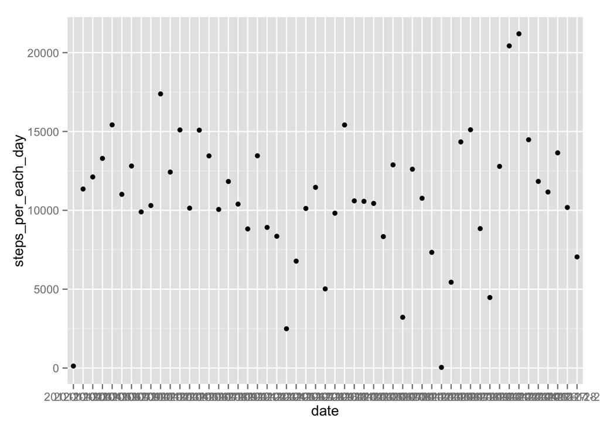

```r
ggplot(data=act1_agg2, aes(x=date, y=steps_per_each_day))+
  geom_bar(color="blue")+
  stat_identity()
```

alt, devo capire bene e questo scatterplot di merda mi ha anche fatto capire che devo esplorare meglio il dataset

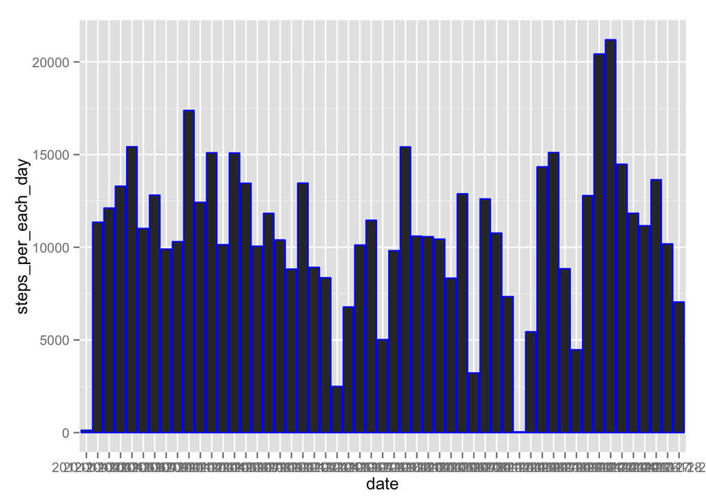

```r
ggplot(data=act1_agg2, aes(x=date, y=steps_per_each_day))+
  geom_bar(color="blue",stat="identity")
```

==========================================

What is the average daily activity pattern?

Make a time series plot (i.e. type = “l”) of the 5-minute interval (x-axis) and the average number of steps taken, averaged across all days (y-axis)

in questo caso devo calcolcare la media per specifico intervallo

```r
act1_agg_int<-group_by(subset(act1,!is.na(steps)), interval)
act1_agg_int2<-summarise(act1_agg_int,
                          mean_steps_per_int=mean(steps),
                          tot=n())
```

modifico i valori dell’intervallo per evitare lo scalino tra 55 e 100

```r
act1_agg_int2$interval2<-seq(0,5*287, 5)
length(act1_agg_int2$interval2)
```

```
## [1] 288
```

**problema, ho corretto il grafico delle media dei passi per intervallo, c’era il problema dello scalino da 55 a 100, ma ora non trovo il modo di etichettare adeguatamente l’asse x**

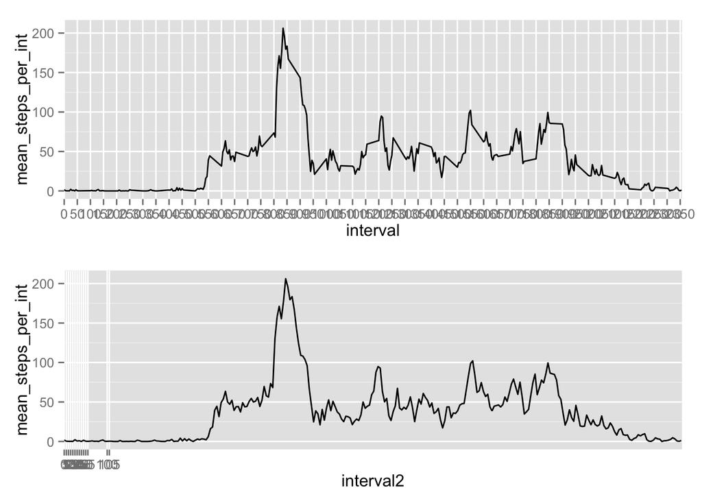

```r
gp1<-ggplot(data=act1_agg_int2, aes(x=interval, y=mean_steps_per_int))+
  geom_line()+
  scale_x_discrete(breaks=seq(0, max(act1_agg_int2$interval), 50))

gp2<-ggplot(data=act1_agg_int2, aes(x=interval2, y=mean_steps_per_int))+
  geom_line()+
  scale_x_discrete(breaks=c('0',
'5',    '10',   '15',   '20',   '25',   '30',   '35',   '40',   '45',   '50',   '55',   '100',"105"))
grid.arrange(gp1, gp2)
```

Which 5-minute interval, on average across all the days in the dataset, contains the maximum number of steps?

```r
act1_agg_int2[which.max(act1_agg_int2$mean_steps_per_int),]
```

```
## Source: local data frame [1 x 4]
##
##   interval mean_steps_per_int tot interval2
## 1      835           206.1698  53       515
```

NA’s

Calculate and report the total number of missing values in the dataset (i.e. the total number of rows with NAs

```r
act1_NA<-subset(act1, !complete.cases(act1))
nrow(act1_NA)
```

```
## [1] 2304
```

Devise a strategy for filling in all of the missing values in the dataset. The strategy does not need to be sophisticated. For example, you could use the mean/median for that day, or the mean for that 5-minute interval, etc

uso la media di passi per intervallo credo dataframe di act1 con la media per intervallo attaccata, e poi riordino

```r
act1_notNA<-merge(x = act1, y = act1_agg_int2, by = "interval", all.x=TRUE)
act1_notNA<-act1_notNA[order(act1_notNA$date,act1_notNA$interval),]

act1_notNA$steps_notNA<-ifelse(is.na(act1_notNA$steps), act1_agg_int2$mean_steps_per_int, act1_notNA$steps)
```

Create a new dataset that is equal to the original dataset but with the missing data filled in.

```r
row.names=FALSE
act2<-subset(act1_notNA, select=c(steps_notNA, date, interval))
act2<-data.frame(act2, row.names=NULL)
library("reshape")
act2<-rename(act2,c(steps_notNA="steps"))
```

Make a histogram of the total number of steps taken each day and Calculate and report the mean and median total number of steps taken per day. Do these values differ from the estimates from the first part of the assignment? What is the impact of imputing missing data on the estimates of the total daily number of steps?

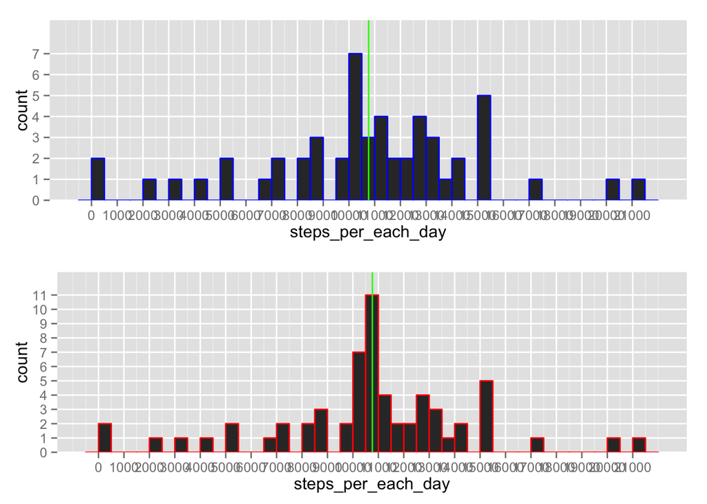

```r
act2_agg<-group_by(act2, date)
act2_agg2<-summarise(act2_agg,
                     steps_per_each_interval_mean=mean(steps),
                     steps_per_each_interval_median=median(steps),
                     steps_per_each_day=sum(steps))

media_notNA<-mean(act2_agg2$steps_per_each_day)
mediana_notNA<-median(act2_agg2$steps_per_each_day)

g2<-ggplot(data=act2_agg2, aes(x=steps_per_each_day))+
  geom_histogram(binwidth=500, color="red")+
  geom_vline(xintercept=mean(act2_agg2$steps_per_each_day), color="green")+
  scale_x_continuous(breaks=seq(0, max(act2_agg2$steps_per_each_day), 1000))+
  scale_y_discrete(breaks=seq(0,11,1))

grid.arrange(g1,g2)
```

le due distribuzioni sono identiche, salvo la classe che include la media (10500-11000) che da frequenza 3 passa a frequenza 11. immagino che la cosa coincida col numero di giorni che hanno misurazioni NA

```r
nrow(act1_NA)/unique(act1_agg2$intervals_per_each_day)==8
```

```
## [1] TRUE
```

```r
nrow(act1_NA)/unique(act1_agg2$intervals_per_each_day)==8
```

```
## [1] TRUE
```

distinguo tra giorni feriali e giorni festivi. devo convertire la variabile date in variabile temporale

```r
act2$date2 <- as.Date(as.character(act2$date), format = "%m/%d/%Y")
act2$date2<-as.POSIXct(as.character(act2$date), format = "%d/%m/%Y")
```